# Calibrating Sagehen Model Streamflow

Author

Caitlin Nordheim-Maestas, Kat Le

# Part 1:

### Combined metric and creating the function

### Function: flow_metrics_mayflies.R

Goal: make a function that creates a combined metric of ecologically important indices for mayfly emergence (See Q5, the discussion section, for justification of these metrics for mayfly emergence!). This function calculates the percent error of the model and true observations, and the correlation values for 2 important indices for mayflies: (1) the entire month of mayfly emergence - for June and July (2) the maximum water flow within that mayfly month, and calculates a combined metric (after adjusting the errors to be on the same scale as the correlation values) for all indices.

```r
# call function
source(here::here("flow_metrics_mayflies.R"))
```

# Part 2:

Libraries & Loading Data

```r
library(sensitivity)
library(tidyverse)
library(purrr)
library(ggpubr)
library(here)
library(gt)

# for Part 1 and getting data for part 2
sager = read.table("sager.txt", header=T)
msage = read.table("sagerm.txt", header=T)
```

sager wrangling

```r
# add date
sager = sager %>%
  mutate(date = paste(day,month,year, sep="/"))
sager$date = as.Date(sager$date,"%d/%m/%Y")
```

msage wrangling

```r
# create simulation names
nsim = ncol(msage)
#snames = sprintf("S%d", seq(from=1, to=nsim))
snames = paste0(seq(from=1, to=nsim))
colnames(msage) = snames

# grab columnn names from sager
msage$date = sager$date
msage$month = sager$month
msage$year = sager$year
msage$day = sager$day
msage$wy = sager$wy

# join for observation data
msage = left_join(msage, sager[,c("obs", "date")],
                  by = c("date"))

# plot our model simulations (code from lecture)
msagel = msage %>%
  pivot_longer(cols=!c(date, month, year, day, wy),
               names_to="run",
               values_to="flow")

# let's look at 1970, because groovy
p1=ggplot(subset(msagel, wy == 1970),
          aes(as.Date(date),
              flow,
              col=run))+
  geom_line()+
  theme(legend.position = "none")

# lets add observed streamflow
finalp1 = p1+
  geom_line(data=subset(sager, wy == 1970),
            aes(as.Date(date),
                obs),
            size=2, col="black",
            linetype=2)+
  labs(y="Streamflow", x="Date") +
  ggtitle("simulated and observed data for 1970")
```

## Q1: Split-sample calibration and answers

**Our calibration period: 1970 to 1980 for calibration.**

### Calibration period

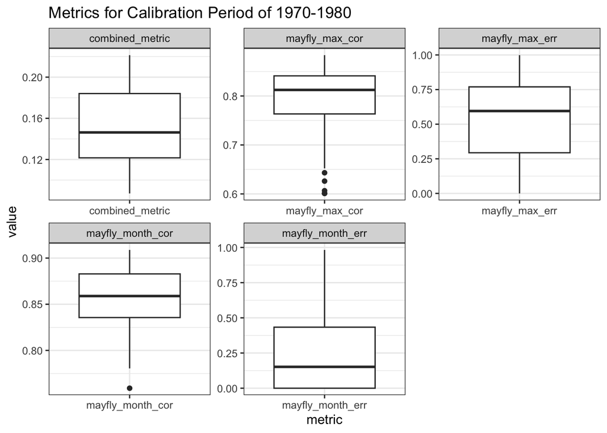

```r
# filter for our calibration period: 1970 - 1980
calibration_period = msage %>%
  filter(year %in% c(1970:1980))

# obtain model results by mapping out function over our calibration period for all parameter sets
calibration_res = calibration_period %>%
  select(-date, -month, -day, -year, -wy, -obs) %>%
  map_df(flow_metrics_mayflies,
         o=calibration_period$obs,
         month=calibration_period$month,
         day=calibration_period$day,
         year=calibration_period$year,
         wy=calibration_period$wy)

# assign simulation names
calibration_res$sim = snames

# make the dataframe longer to allow for boxplot showing range of metrics
calibration_resl = calibration_res %>%
  pivot_longer(-sim, names_to="metric",
               values_to="value")

# boxplot showing the range of the model metrics we used
ggplot(calibration_resl, aes(metric, value)) +
  geom_boxplot() +
  facet_wrap(~metric, scales = "free") +
  labs(title = "Metrics for Calibration Period of 1970-1980") +
  theme_bw()
```

## Q2: Best and worst performance metric

Here, we calculated the best and worst parameter sets for (1) the calibration period and (2) the post-calibration period

```r
###### select best

# best set for calibration period of 1970 - 1980
best_calibrationperiod = calibration_res[which.max(calibration_res$combined_metric),] %>%
  mutate(type = "best_calibrationperiod")

###### select worst

# best worst for calibration period of 1970 - 1980
worst_calibrationperiod = calibration_res[which.min(calibration_res$combined_metric),] %>%
  mutate(type = "worst_calibrationperiod")

# create a table of the best and worst

best_df = rbind.data.frame( best_calibrationperiod,
                           worst_calibrationperiod) %>%
  select(type, sim, combined_metric)

best_df %>%
  gt() %>%
  tab_header(title = "Best and Worst Runs",
             subtitle = "Based Off Combined Metric")
```

Best and Worst Runs

Based Off Combined Metric

| type | sim | combined_metric |
| --- | --- | --- |
| best_calibrationperiod | 81 | 0.22136187 |
| worst_calibrationperiod | 43 | 0.08704106 |

## Q3: Graph something about streamflow for the best parameter set

Here, we show the best parameter set from the CALIBRATION period, 1970 - 1980.

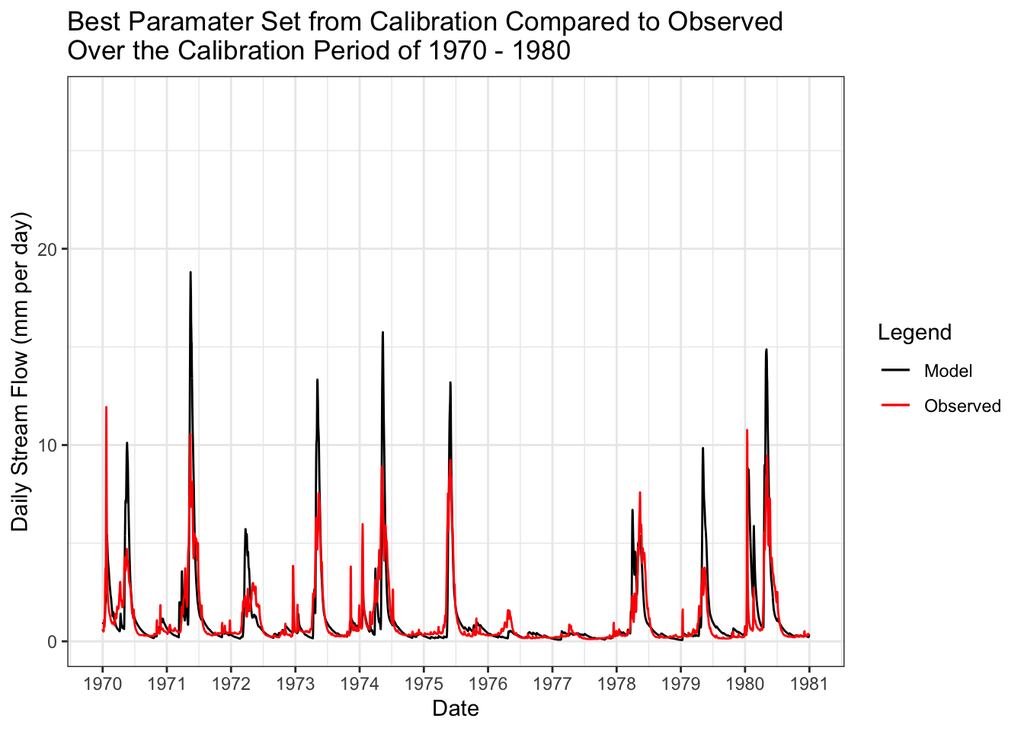

```r
# show model output of best model and observed data over all time within calibration period
ggplot(msage) +
  geom_line(aes(date,
                msage[,best_calibrationperiod$sim],
                color = "Model")) +
  geom_line(aes(date, obs,
                color ="Observed")) +
  labs(title = "Best Paramater Set from Calibration Compared to Observed \nOver the Calibration Period of 1970 - 1980",
       y = "Daily Stream Flow (mm per day)",
       x = "Date",
       color = "Legend") +
  scale_color_manual(values = c("Model" = "black",
                                "Observed" = "red")) +
  scale_x_date(limits = as.Date(c("1970-01-01", "1980-12-31")),
               date_breaks = "1 year",  # Set breaks every year
               date_labels = "%Y") +
  theme_bw()
```

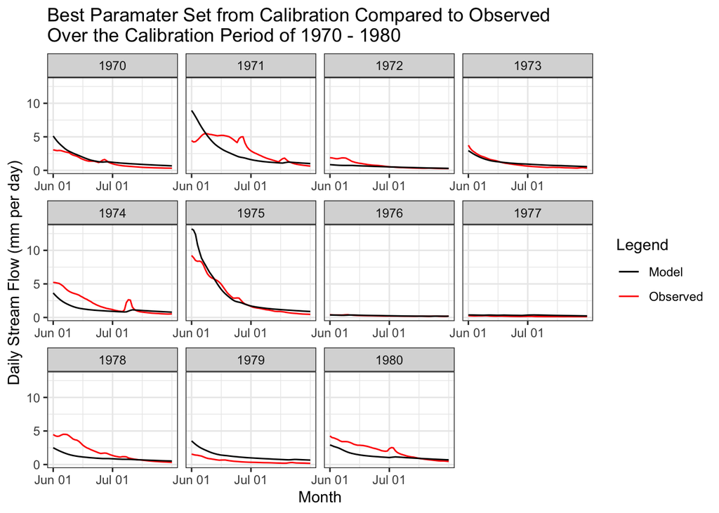

```r
# Create vector of June 1st and July 1st for each year from 1970 to 1980
breaks_dates <- as.Date(unlist(sapply(1970:1980, function(year) {
  c(sprintf("%d-06-01", year), sprintf("%d-07-01", year))
})))

### More ecologically relevant plot: Just june and july

# filter dataframe to just the calibration period (needed to do this to make the faceted plot by year)
msage_filtered <- msage %>%
  filter(format(date, "%Y") %in% c(1970:1980) &
         format(date, "%m") %in% c("06", "07"))

# plot june and july observed and predicted data faceted by year
ggplot(msage_filtered) +
  geom_line(aes(date, obs,
                color ="Observed")) +
  geom_line(aes(date,
                msage_filtered[,best_calibrationperiod$sim],
                color = "Model")) +
  scale_color_manual(values = c("Model" = "black",
                                "Observed" = "red")) +
    scale_x_date(breaks = breaks_dates,
               labels = scales::date_format("%b %d")) +
  facet_wrap(~ format(date, "%Y"), scales = "free_x") +  # Facet by year, free x scales for each facet
  labs(title = "Best Paramater Set from Calibration Compared to Observed \nOver the Calibration Period of 1970 - 1980",
       y = "Daily Stream Flow (mm per day)",
       x = "Month",
       color = "Legend") +
  theme_bw()
```

## Q4: Compute and plot how the performance of the model using the best parameter set changed in pre and post calibration periods (that you chose)

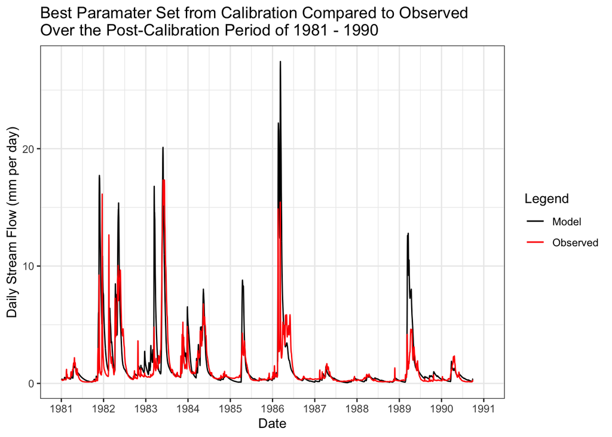

```r
# show model output of best model and observed data over all time over post-calibration period
ggplot(msage) +
  geom_line(aes(date,
                msage[,best_calibrationperiod$sim],
                color = "Model")) +
  geom_line(aes(date, obs,
                color ="Observed")) +
  labs(title = "Best Paramater Set from Calibration Compared to Observed \nOver the Post-Calibration Period of 1981 - 1990",
       y = "Daily Stream Flow (mm per day)",
       x = "Date",
       color = "Legend") +
  scale_color_manual(values = c("Model" = "black",
                                "Observed" = "red")) +
  scale_x_date(limits = as.Date(c("1981-01-01", "1990-12-31")),
               date_breaks = "1 year",  # Set breaks every year
               date_labels = "%Y") +
  theme_bw()
```

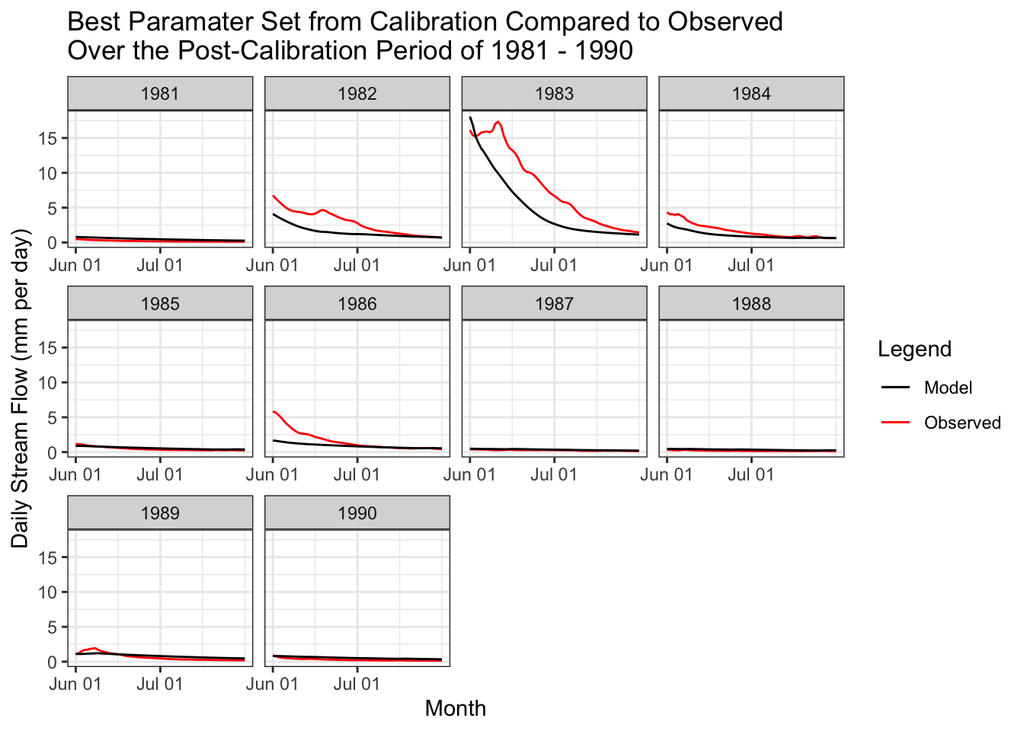

```r
# Ecologically relevant: Just june and july

  # Create vector of June 1st and July 1st for each year from 1981 to 1990
breaks_dates <- as.Date(unlist(sapply(1981:1990, function(year) {
  c(sprintf("%d-06-01", year), sprintf("%d-07-01", year))
})))

# filter dataframe to just the post-calibration period (needed to do this to make the faceted plot by year)
msage_filtered_post <- msage %>%
  filter(format(date, "%Y") %in% c(1981:1990) &
         format(date, "%m") %in% c("06", "07"))

# plot june and july observed and predicted data faceted by year
ggplot(msage_filtered_post) +
  geom_line(aes(date, obs,
                color ="Observed")) +
  geom_line(aes(date,
                msage_filtered_post[,best_calibrationperiod$sim],
                color = "Model")) +
  scale_color_manual(values = c("Model" = "black",
                                "Observed" = "red")) +
    scale_x_date(breaks = breaks_dates,
               labels = scales::date_format("%b %d")) +
  facet_wrap(~ format(date, "%Y"), scales = "free_x") +  # Facet by year, free x scales for each facet
  labs(title = "Best Paramater Set from Calibration Compared to Observed \nOver the Post-Calibration Period of 1981 - 1990",
       y = "Daily Stream Flow (mm per day)",
       x = "Month",
       color = "Legend") +
  theme_bw()
```

## Q5: Discussion

#### Metric justification

This data is taken from Sagehen Creek field station, a reserve that has a lot of research on birds, which monitors many species of birds to model their populations. Many birds rely on emerging insects, like mayflies, as a food source. Mayflies tend to emerge en mass, so it is vital that the timing of the mayfly emergence lines up with when the bird predators are present, especially for migratory species. It has been postulated that an increased stream flow can trigger a delayed in mayfly emerge. A delayed emergence could be detrimental to the birds relying on the mayfly food source, and thus, we will focus on the instances of high streamflow, the maximum, during the months of ecological relevance to mayfly emergence. Thus, we will be using the streamflow model outputs from the Sagehen creek models to determine which parameter set best predicts combined set of metrics of importance (the error and correlation of monthly streamflow and maximum streamflow) in the window of mayfly emergence (the months of June and July).

#### For fun: image of an egret snacking on a mayfly

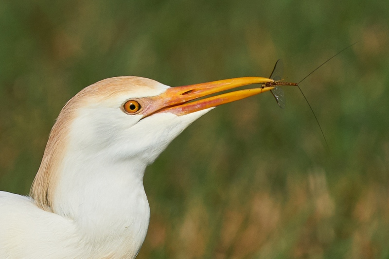

Cattle egret snacking on a mayfly; photo by Arthur Morris

## Appendix

For fun, we also conducted these steps for the WHOLE model period, not split-sample!

### whole sample (not split sample) calibration

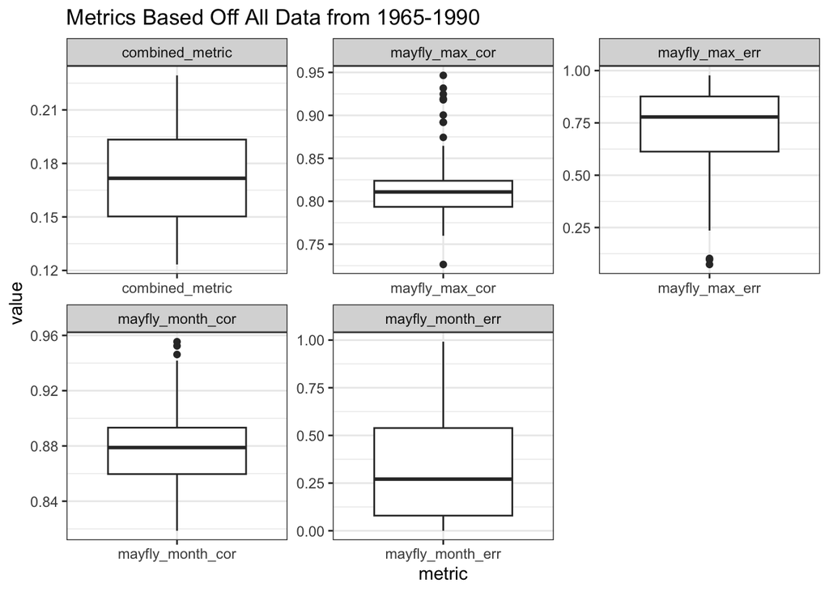

```r
# apply flow_metrics_mayflies function to dataframe
res = msage %>%
  select(-date, -month, -day, -year, -wy, -obs) %>%
  map_df(flow_metrics_mayflies, o=sager$obs,
         month=msage$month, day=msage$day,
         year=msage$year, wy=msage$wy)

# graph range of performance measures
resl = res %>%
  pivot_longer(cols=everything(),
               names_to="metric",
               values_to="value")

ggplot(resl, aes(metric, value)) +
  geom_boxplot()+
  facet_wrap(~metric, scales="free") +
  labs(title = "Metrics Based Off All Data from 1965-1990") +
  theme_bw()
```

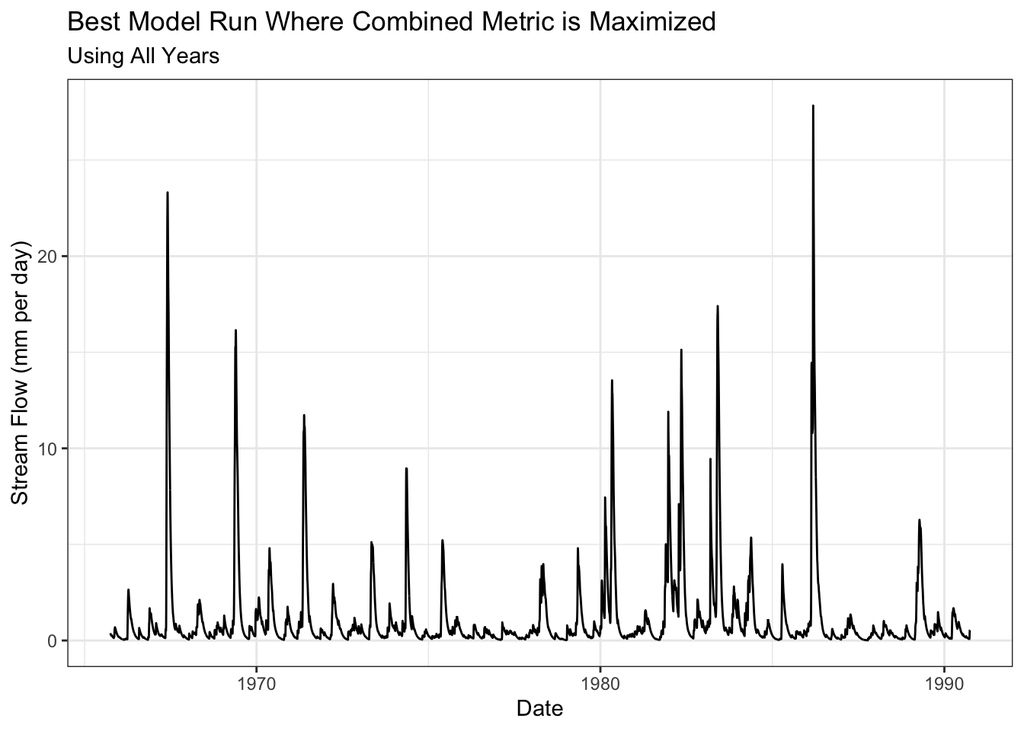

```r
# assign an identifier to each row, use the same identify for columns of original streamflow data
res$sim = seq(from=1,to=nrow(res))
colnames(msage)=c(res$sim, "date","month","year","day","wy", "obs")

# select the best model for which the combined metric is maximized for the WHOLE DATASET
best = res[which.max(res$combined_metric),]

msagel  =  msage %>%
  pivot_longer(cols=!c(date, month, year, day,wy),
               names_to="sim",
               values_to="flow")
ggplot(subset(msagel,
              sim == best$sim),
       aes(date, flow)) +
  geom_line() +
  labs(title = "Best Model Run Where Combined Metric is Maximized",
       subtitle = "Using All Years",
       y = "Stream Flow (mm per day)",
       x = "Date") +
  theme_bw()
```

```r
## best run for the WHOLE dataset is run 89!

# select the best model for our combined metric
best = res[which.max(res$combined_metric),] %>%
  mutate(type = "best")

# select the best model for our combined metric
worst = res[which.min(res$combined_metric),] %>%
  mutate(type = "worst")

best_df = rbind.data.frame(best,worst) %>%
  select(type, sim, combined_metric)

best_df %>%
  gt() %>%
  tab_header(title = "Best and Worst Runs for NOT split sample",
             subtitle = "Based Off Combined Metric")
```

Best and Worst Runs for NOT split sample

Based Off Combined Metric

| type | sim | combined_metric |
| --- | --- | --- |
| best | 89 | 0.2293417 |
| worst | 55 | 0.1233638 |

## Post-calibration “Validation” time period

What would the best parameter set be if we trained the model on 1981 - 1990?

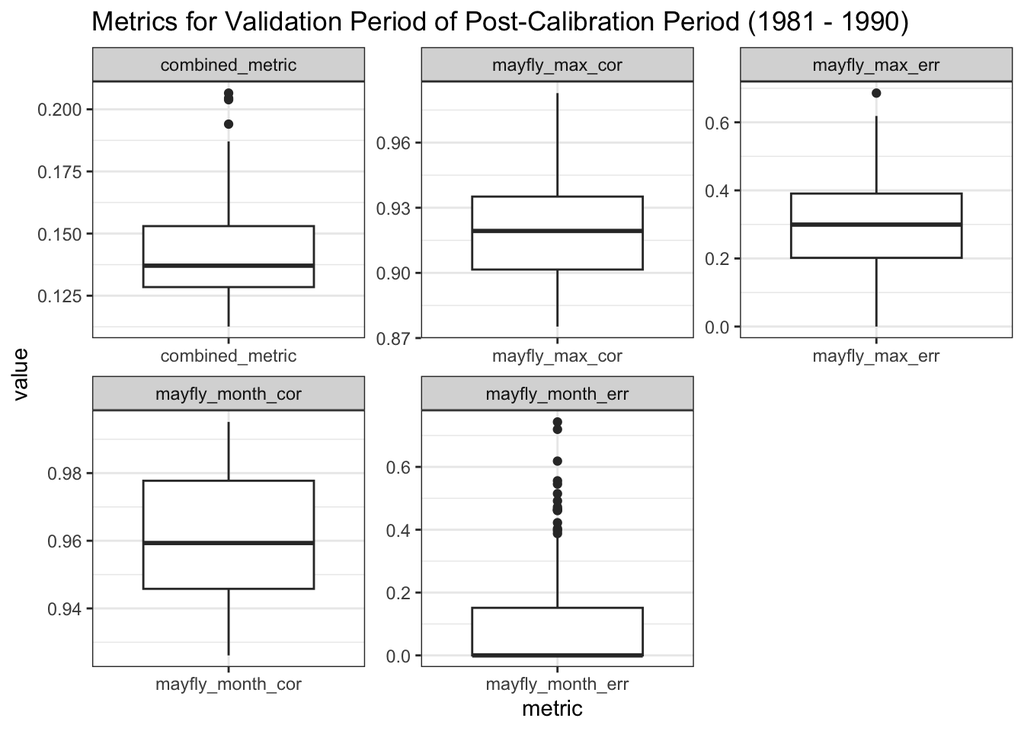

```r
validation_period = msage %>%
 filter(year %in% c(1981:1990))

validation_res = validation_period %>%
  select(-date, -month, -day, -year, -wy, -obs) %>%
  map_df(flow_metrics_mayflies,
         o=validation_period$obs,
         month=validation_period$month,
         day=validation_period$day,
         year=validation_period$year,
         wy=validation_period$wy)


validation_res$sim = snames

validation_resl = validation_res %>%
  pivot_longer(-sim, names_to="metric",
               values_to="value")

ggplot(validation_resl, aes(metric, value)) +
  geom_boxplot() +
  facet_wrap(~metric, scales = "free") +
  labs(title = "Metrics for Validation Period of Post-Calibration Period (1981 - 1990)") +
  theme_bw()
```

```r
# best set for post-calibration period of 1981 - 1990
best_validationperiod = validation_res[which.max(validation_res$combined_metric),] %>%
  mutate(type = "best_validationperiod")

# worst set for post-calibration period of 1981 - 1990
worst_validationperiod = validation_res[which.min(validation_res$combined_metric),] %>%
  mutate(type = "worst_validationperiod")

best_df = rbind.data.frame(
                           best_validationperiod,
                           worst_validationperiod) %>%
  select(type, sim, combined_metric)

best_df %>%
  gt() %>%
  tab_header(title = "Best and Worst Runs",
             subtitle = "Based Off Combined Metric")
```

Best and Worst Runs

Based Off Combined Metric

| type | sim | combined_metric |
| --- | --- | --- |
| best_validationperiod | 87 | 0.2065176 |
| worst_validationperiod | 16 | 0.1125879 |